# Tools Comparison (Simple): Claude Code + Sonnet 4.6

## Run Metadata

- Harness: `claude-code`
- Model: `sonnet-4-6`
- Prompt type: `simple`

## Setup

```r
library(dplyr)

df <- readr::read_csv(here::here("data/synthetic/simulated_maternal_health_data.csv"))
```

## Prompt

```
Study this data set (`data/synthetic/simulated_maternal_health_data.csv`), show me descriptive statistics, pick a modeling strategy, and report the model. Be thorough.
```

## Response

### Data Overview

```r
dim(df)
```

```
[1] 50000    20
```

```r
str(df)
```

```
spc_tbl_ [50,000 × 20] (S3: spec_tbl_df/tbl_df/tbl/data.frame)
 $ id                                   : num [1:50000] 1 2 3 4 5 6 7 8 9 10 ...
 $ provider_id                          : num [1:50000] 1 1 1 1 1 1 1 1 1 1 ...
 $ state                                : chr [1:50000] "AK" "AK" "AK" "AK" ...
 $ received_comprehensive_postnatal_care: num [1:50000] 0 1 0 0 0 1 1 1 0 0 ...
 $ self_report_income                   : chr [1:50000] "$50,000–$74,999" "$50,000–$74,999" "$50,000–$74,999" "$25,000–$49,999" ...
 $ age                                  : num [1:50000] 31 26 33 37 21 33 25 34 29 38 ...
 $ edu                                  : chr [1:50000] "hs" "hs" "some_college" "hs" ...
 $ race_ethnicity                       : chr [1:50000] "white" "white" "white" "asian" ...
 $ insurance                            : chr [1:50000] "no_insurance" "no_insurance" "no_insurance" "private" ...
 $ job_type                             : chr [1:50000] "unskilled" "unskilled" "unskilled" "professional" ...
 $ dependents                           : num [1:50000] 2 2 2 2 2 2 2 3 3 3 ...
 $ distance_to_provider                 : num [1:50000] 1.789 10.899 35.122 4.914 0.958 ...
 $ obesity                              : num [1:50000] 0 0 1 0 1 1 1 1 1 1 ...
 $ multiple_gestation                   : num [1:50000] 0 0 0 0 0 1 0 1 0 0 ...
 $ diabetes                             : num [1:50000] 0 0 0 0 0 0 0 0 0 0 ...
 $ heart_disease                        : num [1:50000] 0 0 0 1 0 0 1 0 0 0 ...
 $ placenta_previa                      : num [1:50000] 0 0 0 0 0 0 0 0 0 0 ...
 $ hypertension                         : num [1:50000] 0 0 1 0 0 1 0 0 0 0 ...
 $ gest_hypertension                    : num [1:50000] 0 0 0 0 0 0 0 0 0 0 ...
 $ preeclampsia                         : num [1:50000] 0 0 0 0 0 0 0 0 0 0 ...
 - attr(*, "spec")=
  .. cols(
  ..   id = col_double(),
  ..   provider_id = col_double(),
  ..   state = col_character(),
  ..   received_comprehensive_postnatal_care = col_double(),
  ..   self_report_income = col_character(),
  ..   age = col_double(),
  ..   edu = col_character(),
  ..   race_ethnicity = col_character(),
  ..   insurance = col_character(),
  ..   job_type = col_character(),
  ..   dependents = col_double(),
  ..   distance_to_provider = col_double(),
  ..   obesity = col_double(),
  ..   multiple_gestation = col_double(),
  ..   diabetes = col_double(),
  ..   heart_disease = col_double(),
  ..   placenta_previa = col_double(),
  ..   hypertension = col_double(),
  ..   gest_hypertension = col_double(),
  ..   preeclampsia = col_double()
  .. )
 - attr(*, "problems")=<externalptr>
```

The dataset contains 50,000 observations of maternal health records with 20 variables including demographics, insurance status, geographic access, and clinical indicators.

### Clean and Type Variables

```r
income_levels <- c(
  "Under $25,000",
  "$25,000–$49,999",
  "$50,000–$74,999",
  "$75,000–$99,999",
  "$100,000 or more"
)

edu_levels <- c("less_than_hs", "hs", "some_college", "bachelors", "graduate")

df <- df |>
  mutate(
    self_report_income = factor(self_report_income, levels = income_levels, ordered = TRUE),
    edu = factor(edu, levels = edu_levels, ordered = TRUE),
    race_ethnicity = factor(race_ethnicity),
    insurance = factor(insurance),
    job_type = factor(job_type),
    state = factor(state)
  )
```

### Descriptive Statistics

#### Missingness

```r
colSums(is.na(df))
```

```
                                   id                           provider_id
                                    0                                     0
                                state received_comprehensive_postnatal_care
                                    0                                     0
                   self_report_income                                   age
                                 4227                                     0
                                  edu                        race_ethnicity
                                 6715                                     0
                            insurance                              job_type
                                    0                                     0
                           dependents                  distance_to_provider
                                    0                                     0
                              obesity                    multiple_gestation
                                    0                                     0
                             diabetes                         heart_disease
                                    0                                     0
                      placenta_previa                          hypertension
                                    0                                     0
                    gest_hypertension                          preeclampsia
                                    0                                     0
```

#### Numeric Summaries

```r
df |>
  select(where(is.numeric), -id, -provider_id) |>
  tidyr::pivot_longer(everything(), names_to = "variable", values_to = "value") |>
  group_by(variable) |>
  summarise(
    n = n(),
    mean = mean(value, na.rm = TRUE),
    sd = sd(value, na.rm = TRUE),
    min = min(value, na.rm = TRUE),
    q25 = quantile(value, 0.25, na.rm = TRUE),
    median = median(value, na.rm = TRUE),
    q75 = quantile(value, 0.75, na.rm = TRUE),
    max = max(value, na.rm = TRUE),
    .groups = "drop"
  ) |>
  knitr::kable(digits = 2)
```

| variable | n | mean | sd | min | q25 | median | q75 | max |
| --- | --- | --- | --- | --- | --- | --- | --- | --- |
| age | 50000 | 28.02 | 6.26 | 15 | 23.0 | 28 | 32.00 | 44.00 |
| dependents | 50000 | 2.38 | 0.95 | 0 | 2.0 | 2 | 3.00 | 8.00 |
| diabetes | 50000 | 0.10 | 0.30 | 0 | 0.0 | 0 | 0.00 | 1.00 |
| distance_to_provider | 50000 | 14.52 | 14.59 | 0 | 4.1 | 10 | 20.24 | 163.42 |
| gest_hypertension | 50000 | 0.05 | 0.22 | 0 | 0.0 | 0 | 0.00 | 1.00 |
| heart_disease | 50000 | 0.15 | 0.36 | 0 | 0.0 | 0 | 0.00 | 1.00 |
| hypertension | 50000 | 0.20 | 0.40 | 0 | 0.0 | 0 | 0.00 | 1.00 |
| multiple_gestation | 50000 | 0.03 | 0.17 | 0 | 0.0 | 0 | 0.00 | 1.00 |
| obesity | 50000 | 0.35 | 0.48 | 0 | 0.0 | 0 | 1.00 | 1.00 |
| placenta_previa | 50000 | 0.01 | 0.10 | 0 | 0.0 | 0 | 0.00 | 1.00 |
| preeclampsia | 50000 | 0.02 | 0.14 | 0 | 0.0 | 0 | 0.00 | 1.00 |
| received_comprehensive_postnatal_care | 50000 | 0.32 | 0.47 | 0 | 0.0 | 0 | 1.00 | 1.00 |

#### Categorical Summaries

```r
cat("--- Outcome: Received Comprehensive Postnatal Care ---\n")
```

```
--- Outcome: Received Comprehensive Postnatal Care ---
```

```r
table(df$received_comprehensive_postnatal_care)
```

```
    0     1
33851 16149
```

```r
cat("Rate:", mean(df$received_comprehensive_postnatal_care), "\n\n")
```

```
Rate: 0.32298
```

```r
cat("--- Insurance ---\n")
```

```
--- Insurance ---
```

```r
table(df$insurance)
```

```
  no_insurance        private state_provided
         20810          17908          11282
```

```r
cat("\n--- Race/Ethnicity ---\n")
```

```
--- Race/Ethnicity ---
```

```r
table(df$race_ethnicity)
```

```
    aian    asian    black hispanic     nhpi    other    white
     387     3059     5878     8792       90      283    31511
```

```r
cat("\n--- Education ---\n")
```

```
--- Education ---
```

```r
table(df$edu)
```

```
less_than_hs           hs some_college    bachelors     graduate
        5218        23108        14959            0            0
```

```r
cat("\n--- Income ---\n")
```

```
--- Income ---
```

```r
table(df$self_report_income)
```

```
   Under $25,000  $25,000–$49,999  $50,000–$74,999  $75,000–$99,999
               0            14710            21279             9784
$100,000 or more
               0
```

```r
cat("\n--- Job Type ---\n")
```

```
--- Job Type ---
```

```r
table(df$job_type)
```

```
professional        trade   unemployed    unskilled
       14293         6298         2217        27192
```

### Visualizations

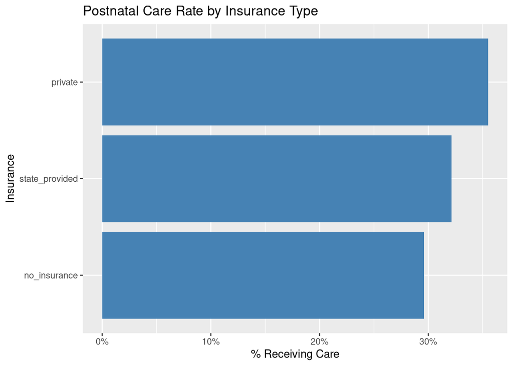

Postnatal care rate by insurance type

```r
library(ggplot2)

df |>
  group_by(insurance) |>
  summarise(pct = mean(received_comprehensive_postnatal_care), .groups = "drop") |>
  ggplot(aes(x = reorder(insurance, pct), y = pct)) +
  geom_col(fill = "steelblue") +
  scale_y_continuous(labels = scales::percent_format()) +
  coord_flip() +
  labs(x = "Insurance", y = "% Receiving Care",
       title = "Postnatal Care Rate by Insurance Type")
```

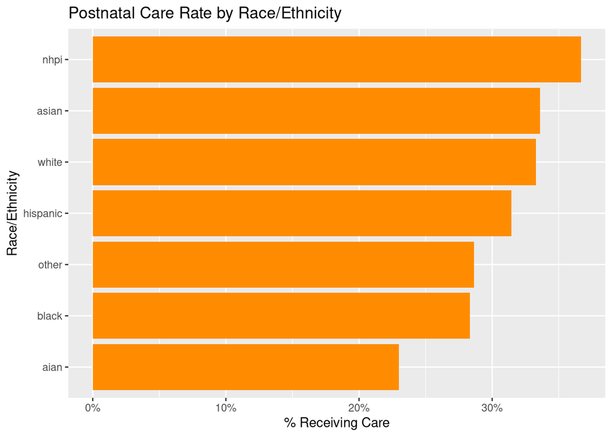

Postnatal care rate by race/ethnicity

```r
df |>
  group_by(race_ethnicity) |>
  summarise(pct = mean(received_comprehensive_postnatal_care), .groups = "drop") |>
  ggplot(aes(x = reorder(race_ethnicity, pct), y = pct)) +
  geom_col(fill = "darkorange") +
  scale_y_continuous(labels = scales::percent_format()) +
  coord_flip() +
  labs(x = "Race/Ethnicity", y = "% Receiving Care",
       title = "Postnatal Care Rate by Race/Ethnicity")
```

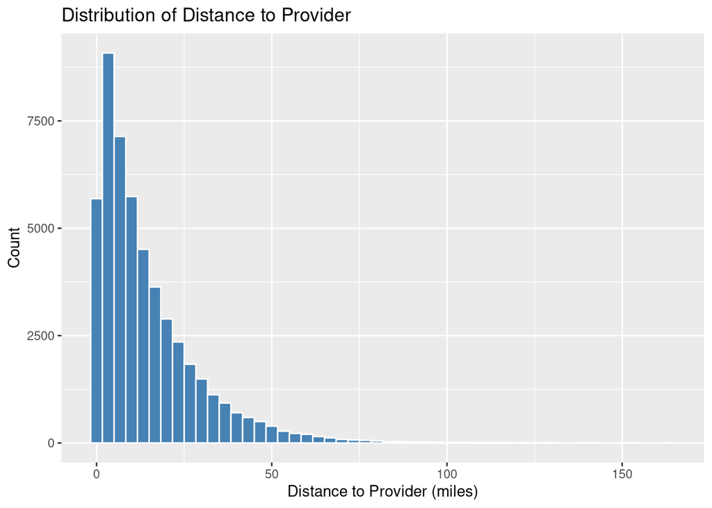

Distribution of distance to provider

```r
ggplot(df, aes(x = distance_to_provider)) +
  geom_histogram(bins = 50, fill = "steelblue", color = "white") +
  labs(x = "Distance to Provider (miles)", y = "Count",
       title = "Distribution of Distance to Provider")
```

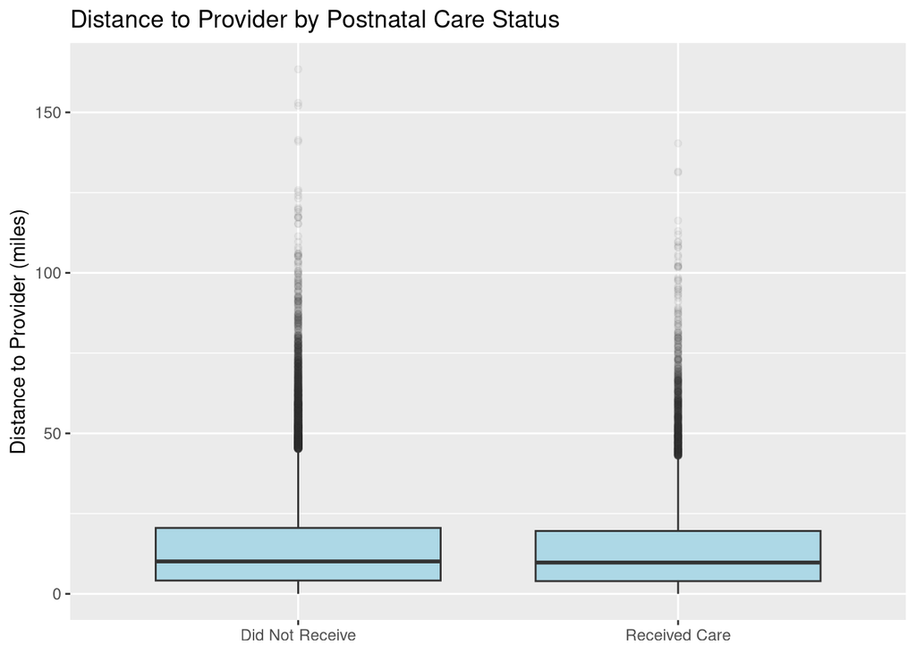

Distance to provider by postnatal care status

```r
df |>
  mutate(care = ifelse(received_comprehensive_postnatal_care == 1,
                        "Received Care", "Did Not Receive")) |>
  ggplot(aes(x = care, y = distance_to_provider)) +
  geom_boxplot(fill = "lightblue", outlier.alpha = 0.05) +
  labs(x = NULL, y = "Distance to Provider (miles)",
       title = "Distance to Provider by Postnatal Care Status")
```

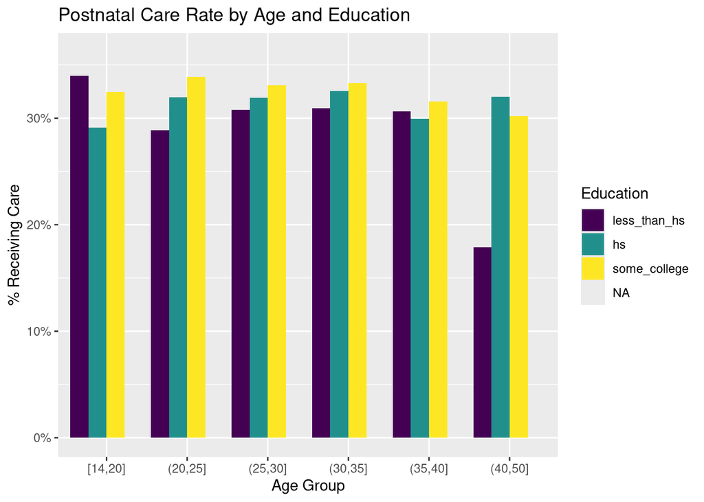

Postnatal care rate by age group and education

```r
df |>
  mutate(age_group = cut(age, breaks = c(14, 20, 25, 30, 35, 40, 50),
                         include.lowest = TRUE)) |>
  group_by(age_group, edu) |>
  summarise(pct = mean(received_comprehensive_postnatal_care), .groups = "drop") |>
  ggplot(aes(x = age_group, y = pct, fill = edu)) +
  geom_col(position = "dodge") +
  scale_y_continuous(labels = scales::percent_format()) +
  labs(x = "Age Group", y = "% Receiving Care", fill = "Education",
       title = "Postnatal Care Rate by Age and Education")
```

### Modeling Strategy

The outcome `received_comprehensive_postnatal_care` is binary (0/1), making logistic regression the natural choice. We will fit a multivariable logistic regression to estimate the association between demographic, socioeconomic, and clinical factors and the probability of receiving comprehensive postnatal care.

#### Fit the Model

```r
model <- glm(
  received_comprehensive_postnatal_care ~ age + edu + race_ethnicity +
    insurance + self_report_income + job_type + dependents +
    distance_to_provider + obesity + multiple_gestation + diabetes +
    heart_disease + placenta_previa + hypertension + gest_hypertension +
    preeclampsia,
  data = df,
  family = binomial(link = "logit")
)

summary(model)
```

```
Call:
glm(formula = received_comprehensive_postnatal_care ~ age + edu +
    race_ethnicity + insurance + self_report_income + job_type +
    dependents + distance_to_provider + obesity + multiple_gestation +
    diabetes + heart_disease + placenta_previa + hypertension +
    gest_hypertension + preeclampsia, family = binomial(link = "logit"),
    data = df)

Coefficients:
                          Estimate Std. Error z value Pr(>|z|)
(Intercept)             -1.0404681  0.1460113  -7.126 1.03e-12 ***
age                     -0.0020076  0.0018519  -1.084 0.278322
edu.L                    0.0271221  0.0278527   0.974 0.330171
edu.Q                    0.0011246  0.0194321   0.058 0.953850
race_ethnicityasian      0.4291260  0.1412143   3.039 0.002375 **
race_ethnicityblack      0.1997168  0.1383754   1.443 0.148937
race_ethnicityhispanic   0.3511144  0.1369437   2.564 0.010349 *
race_ethnicitynhpi       0.4871911  0.2822150   1.726 0.084291 .
race_ethnicityother      0.2241138  0.2048404   1.094 0.273915
race_ethnicitywhite      0.4153404  0.1351387   3.073 0.002116 **
insuranceprivate         0.1660583  0.0284123   5.845 5.08e-09 ***
insurancestate_provided  0.0798141  0.0286148   2.789 0.005283 **
self_report_income.L     0.0824809  0.0214529   3.845 0.000121 ***
self_report_income.Q     0.0089952  0.0178842   0.503 0.614987
job_typetrade            0.0151689  0.0392259   0.387 0.698973
job_typeunemployed      -0.0282525  0.0621294  -0.455 0.649300
job_typeunskilled       -0.1373398  0.0329309  -4.171 3.04e-05 ***
dependents              -0.0169627  0.0132219  -1.283 0.199519
distance_to_provider    -0.0024420  0.0007526  -3.245 0.001175 **
obesity                  0.0078188  0.0238161   0.328 0.742686
multiple_gestation      -0.0639468  0.0677329  -0.944 0.345117
diabetes                 0.1063198  0.0361190   2.944 0.003244 **
heart_disease            0.0754191  0.0301852   2.499 0.012470 *
placenta_previa         -0.0191736  0.1159871  -0.165 0.868702
hypertension             0.0614319  0.0282511   2.174 0.029668 *
gest_hypertension        0.0178042  0.0508283   0.350 0.726127
preeclampsia             0.0578422  0.0787614   0.734 0.462707
---
Signif. codes:  0 '***' 0.001 '**' 0.01 '*' 0.05 '.' 0.1 ' ' 1

(Dispersion parameter for binomial family taken to be 1)

    Null deviance: 49448  on 39580  degrees of freedom
Residual deviance: 49212  on 39554  degrees of freedom
  (10419 observations deleted due to missingness)
AIC: 49266

Number of Fisher Scoring iterations: 4
```

#### Odds Ratios

```r
or_table <- data.frame(
  OR = exp(coef(model)),
  CI_lower = exp(confint.default(model)[, 1]),
  CI_upper = exp(confint.default(model)[, 2]),
  p_value = coef(summary(model))[, "Pr(>|z|)"]
)

knitr::kable(or_table, digits = 3,
             caption = "Odds Ratios with 95% CI")
```

Odds Ratios with 95% CI

|  | OR | CI_lower | CI_upper | p_value |
| --- | --- | --- | --- | --- |
| (Intercept) | 0.353 | 0.265 | 0.470 | 0.000 |
| age | 0.998 | 0.994 | 1.002 | 0.278 |
| edu.L | 1.027 | 0.973 | 1.085 | 0.330 |
| edu.Q | 1.001 | 0.964 | 1.040 | 0.954 |
| race_ethnicityasian | 1.536 | 1.165 | 2.026 | 0.002 |
| race_ethnicityblack | 1.221 | 0.931 | 1.601 | 0.149 |
| race_ethnicityhispanic | 1.421 | 1.086 | 1.858 | 0.010 |
| race_ethnicitynhpi | 1.628 | 0.936 | 2.830 | 0.084 |
| race_ethnicityother | 1.251 | 0.837 | 1.869 | 0.274 |
| race_ethnicitywhite | 1.515 | 1.162 | 1.974 | 0.002 |
| insuranceprivate | 1.181 | 1.117 | 1.248 | 0.000 |
| insurancestate_provided | 1.083 | 1.024 | 1.146 | 0.005 |
| self_report_income.L | 1.086 | 1.041 | 1.133 | 0.000 |
| self_report_income.Q | 1.009 | 0.974 | 1.045 | 0.615 |
| job_typetrade | 1.015 | 0.940 | 1.096 | 0.699 |
| job_typeunemployed | 0.972 | 0.861 | 1.098 | 0.649 |
| job_typeunskilled | 0.872 | 0.817 | 0.930 | 0.000 |
| dependents | 0.983 | 0.958 | 1.009 | 0.200 |
| distance_to_provider | 0.998 | 0.996 | 0.999 | 0.001 |
| obesity | 1.008 | 0.962 | 1.056 | 0.743 |
| multiple_gestation | 0.938 | 0.821 | 1.071 | 0.345 |
| diabetes | 1.112 | 1.036 | 1.194 | 0.003 |
| heart_disease | 1.078 | 1.016 | 1.144 | 0.012 |
| placenta_previa | 0.981 | 0.782 | 1.231 | 0.869 |
| hypertension | 1.063 | 1.006 | 1.124 | 0.030 |
| gest_hypertension | 1.018 | 0.921 | 1.125 | 0.726 |
| preeclampsia | 1.060 | 0.908 | 1.236 | 0.463 |

#### Model Diagnostics

```r
cat("AIC:", AIC(model), "\n")
```

```
AIC: 49265.77
```

```r
cat("Null deviance:", model$null.deviance, "on", model$df.null, "df\n")
```

```
Null deviance: 49447.92 on 39580 df
```

```r
cat("Residual deviance:", model$deviance, "on", model$df.residual, "df\n")
```

```
Residual deviance: 49211.77 on 39554 df
```

```r
cat("McFadden pseudo-R²:", 1 - (model$deviance / model$null.deviance), "\n")
```

```
McFadden pseudo-R²: 0.00477571
```

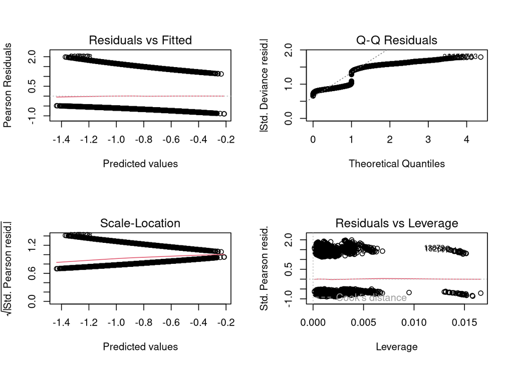

Residual diagnostics

```r
par(mfrow = c(2, 2))
plot(model)
```

```r
par(mfrow = c(1, 1))
```

#### Predictive Performance

```r
predicted_prob <- model$fitted.values
predicted_class <- ifelse(predicted_prob > 0.5, 1, 0)
actual <- model$y

confusion <- table(Predicted = predicted_class,
                   Actual = actual)
confusion
```

```
         Actual
Predicted     0     1
        0 27031 12550
```

```r
accuracy <- sum(diag(confusion)) / sum(confusion)
cat("Accuracy:", round(accuracy, 3), "\n")
```

```
Accuracy: 0.683
```

### Summary

**Limitations:**

- This is an observational, cross-sectional dataset. Associations should not be interpreted as causal effects.
- Observations are nested within providers and states, but this model does not account for clustering. A multilevel model would be more appropriate.
- Self-reported income is measured in broad brackets and may be imprecise.
- The data are synthetic, so findings demonstrate the workflow rather than real-world conclusions.